# Species Distribution Modeling

Camille Ross

8/11/2020

## Install and load necessary packages

```r
# Install packages
installed <- rownames(installed.packages())
if (!("robis" %in% installed)){
   if (!("remotes" %in% installed))install.packages("remotes")
   remotes::install_github("iobis/robis")
}
if (!("ohwobpg" %in% installed)){
  remotes::install_github("BigelowLab/ohwobpg", quiet = TRUE)
}

# Load libraries
library(robis, quietly = TRUE)
library(ohwobpg, quietly = TRUE)
library(dplyr, quietly = TRUE)
library(biomod2, quietly = TRUE)
library(ggplot2, quietly = TRUE)
library(raster, quietly = TRUE)
library(viridis, quietly = TRUE)
```

## Fetching M. novaeangliae occurences

OBIS contains global location data for marine taxa.

Here, we will fetch humpback whale, or M. novaeangliae, occurrence data.

For more information on fetching occurrences, see 08-OBIS-access.ipynb in the 08 R tutorials folder.

```r
M.novaeangliae <- robis::occurrence("Megaptera novaeangliae")
```

[output not shown]

## Plot occurrences

Next, let’s plot the M. novaeangliae occurrences on a map to take a closer look at the data

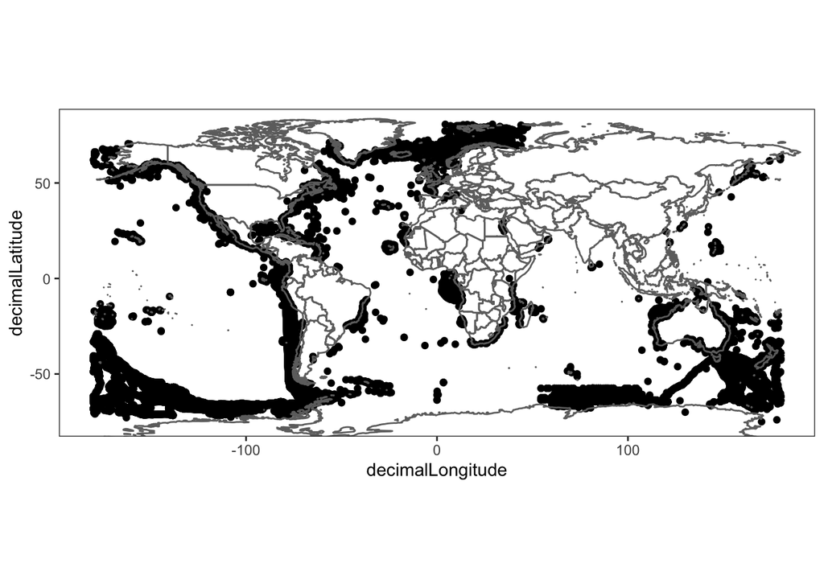

```r
# Load world map data
worldmap <- ggplot2::map_data("world")

# Plot occurrences on world map
ggplot2::ggplot(data = M.novaeangliae, mapping = aes(x = decimalLongitude, y = decimalLatitude)) +
  # Add occurrence data
  geom_point() +
  # Add map data
  geom_polygon(data = worldmap, aes(long, lat, group = group), fill = NA, colour = "gray43") +
        coord_quickmap(xlim = c(round(min(M.novaeangliae$decimalLongitude)),
                                round(max(M.novaeangliae$decimalLongitude))),
                       ylim = c(round(min(M.novaeangliae$decimalLatitude)),
                                round(max(M.novaeangliae$decimalLatitude))),
                       expand = TRUE) +
  # Clean up theme
  theme_bw() +
  theme(panel.grid.major = element_blank(), panel.grid.minor = element_blank())
```

From this plot, we can see that our dataset is pretty extensive

## Load OBPG environmental data

```r
# Load database
path <- "~/mab"
dir.create(path, recursive = TRUE, showWarnings = FALSE)

dates <- seq(
  from = as.Date("2018-01-01"),
  to = as.Date("2018-12-01"),
  by = "month")

# then we build the URLs
urls1 <- obpg_build_url(
  dates = dates,
  param = "chlor_a",
  suite = "CHL",
  period = "MO",
  res = "9km")

urls2 <- obpg_build_url(
  dates = dates,
  param = "sst",
  suite = "SST",
  period = "MO",
  res = "9km")

BB <- c(-75, 0, 35, 56)
nc1 <- obpg_open(urls1[1])
nc2 <- obpg_open(urls2[1])
nav1 <- obpg_nc_nav(nc1,
  bb = BB,
  res = obpg_res(what = "9km"),
  varname = "chlor_a")
nav2 <- obpg_nc_nav(nc2,
  bb = BB,
  res = obpg_res(what = "9km"),
  varname = "sst")

for (this_url in urls1){
  cat("fetching", basename(this_url), "\n")
  new_data <- obpg_fetch(this_url, nav1, outpath = path)
}
```

```
## fetching A20180012018031.L3m_MO_CHL_chlor_a_9km.nc
## fetching A20180322018059.L3m_MO_CHL_chlor_a_9km.nc
## fetching A20180602018090.L3m_MO_CHL_chlor_a_9km.nc
## fetching A20180912018120.L3m_MO_CHL_chlor_a_9km.nc
## fetching A20181212018151.L3m_MO_CHL_chlor_a_9km.nc
## fetching A20181522018181.L3m_MO_CHL_chlor_a_9km.nc
## fetching A20181822018212.L3m_MO_CHL_chlor_a_9km.nc
## fetching A20182132018243.L3m_MO_CHL_chlor_a_9km.nc
## fetching A20182442018273.L3m_MO_CHL_chlor_a_9km.nc
## fetching A20182742018304.L3m_MO_CHL_chlor_a_9km.nc
## fetching A20183052018334.L3m_MO_CHL_chlor_a_9km.nc
## fetching A20183352018365.L3m_MO_CHL_chlor_a_9km.nc
```

```r
for (this_url in urls2){
  cat("fetching", basename(this_url), "\n")
  new_data <- obpg_fetch(this_url, nav2, outpath = path)
}
```

```
## fetching AQUA_MODIS.20180101_20180131.L3m.MO.SST.sst.9km.nc
## fetching AQUA_MODIS.20180201_20180228.L3m.MO.SST.sst.9km.nc
## fetching AQUA_MODIS.20180301_20180331.L3m.MO.SST.sst.9km.nc
## fetching AQUA_MODIS.20180401_20180430.L3m.MO.SST.sst.9km.nc
## fetching AQUA_MODIS.20180501_20180531.L3m.MO.SST.sst.9km.nc
## fetching AQUA_MODIS.20180601_20180630.L3m.MO.SST.sst.9km.nc
## fetching AQUA_MODIS.20180701_20180731.L3m.MO.SST.sst.9km.nc
## fetching AQUA_MODIS.20180801_20180831.L3m.MO.SST.sst.9km.nc
## fetching AQUA_MODIS.20180901_20180930.L3m.MO.SST.sst.9km.nc
## fetching AQUA_MODIS.20181001_20181031.L3m.MO.SST.sst.9km.nc
## fetching AQUA_MODIS.20181101_20181130.L3m.MO.SST.sst.9km.nc
## fetching AQUA_MODIS.20181201_20181231.L3m.MO.SST.sst.9km.nc
```

```r
db <- list.files(path, pattern = glob2rx("*.tif"), full.names = TRUE, recursive = TRUE) %>%
  as_database() %>%
  write_database(path)
db <- read_database(path)

# Load sst ----
sst_db <- db %>%
  dplyr::filter(param == "sst" &
                per == "MO" &
                dplyr::between(date, as.Date("2018-05-15"), as.Date("2018-09-26")))

# Create raster stack
sst <- sst_db %>%                # start with the subset database
  as_filename(path = path) %>%   # build filenames and append to the path
  raster::stack()                # read them into a stack of images

# Name layers
names(sst) <- format(sst_db$date, "%b")

# Load chlor_a ----
chlor_a_db <- db %>%
  dplyr::filter(param == "chlor_a" &
                per == "MO" &
                dplyr::between(date, as.Date("2018-05-15"), as.Date("2018-09-26")))

# Create raster stack
chlor_a <- chlor_a_db %>%                # start with the subset database
  as_filename(path = path) %>%   # build filenames and append to the path
  raster::stack()                # read them into a stack of images

# Name layers
names(chlor_a) <- format(chlor_a_db$date, "%b")

# Remove lakes from SST ----
sst[is.na(chlor_a)] <- NA
```

## Subset M. novaeangliae data

Next, we will subset the M. novaeangliae data so it’s in the same bounding box as our environmental data. We will also subset to only include occurrence records from August, which is the peak feeding season for M. novaeangliae in the Gulf of Maine.

```r
M.novaeangliae.subset <- M.novaeangliae %>%
  # Shorten names
  dplyr::rename(lon = decimalLongitude,
                lat = decimalLatitude) %>%
  # Filter to bounding box and select month of August
  dplyr::filter(lon >= BB[1] & lon <= BB[2] &
                lat >= BB[3] & lat <= BB[4] &
                month == "08") %>%
  # Select relevant columns
  dplyr::select(lon, lat)
```

## Add background points

We need to add a column for binary presence/absence in order to model the species’ distribution with biomod2. Because the dataset only includes presences, we first need to select random backgroun points. Next, we will add a column containing a 1 to our occurrence dataset and a column containing a zero to the background points dataset. Then, the two datasets are combined into one presence/absence dataframe.

```r
# Add presence/absence code
# Add unique latitude and longitude code
M.novaeangliae.biomod <- M.novaeangliae.subset %>%
  dplyr::mutate(pa = 1, code = paste0(lon, lat))

# Add background points
# Select points using unique latitude and longitude code
background_locs <- as.data.frame(sst$Aug, xy = TRUE) %>%
  dplyr::rename(lon = x, lat = y) %>%
  sample_n(500) %>%
  dplyr::mutate(pa = 0, code = paste0(lon, lat)) %>%
  dplyr::filter(!(code %in% M.novaeangliae.biomod$code) & !is.na(Aug)) %>%
  dplyr::select(lon, lat, pa, code)

# Combine occurrence data and background points
M.novaeangliae.biomod <- rbind(M.novaeangliae.biomod, background_locs)
```

## Plot occurrences with background points

Next, we will plot the occurrences again to ensure they are within the bounding box and do not overlap with the background points. To determine this, we will plot the points on top of the SST layer.

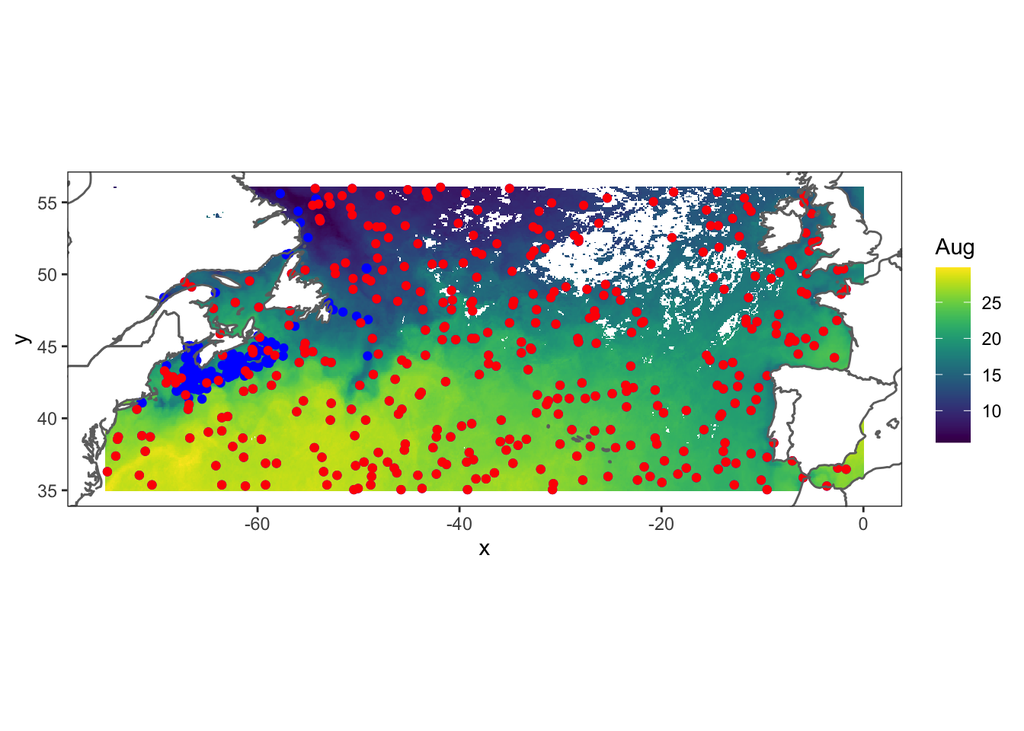

```r
# Plot occurrences and background points on top of sst data
ggplot2::ggplot() +
  geom_tile(data = as.data.frame(sst$Aug, xy = TRUE), mapping = aes(x = x, y = y, fill = Aug)) +
  scale_fill_viridis(na.value = "white") +
  # Add occurrence data
  geom_point(data = M.novaeangliae.biomod, mapping = aes(x = lon, y = lat), color = "blue") +
  # Add background data
  geom_point(data = background_locs, mapping = aes(x = lon, y = lat), color = "red") +
  # Add map data
  geom_polygon(data = worldmap, aes(long, lat, group = group), fill = NA, colour = "gray43") +
  coord_quickmap(xlim = c(xmin(sst),
                          xmax(sst)),
                 ylim = c(ymin(sst),
                          ymax(sst)),
                 expand = TRUE) +
  # Clean up theme
  theme_bw() +
  theme(panel.grid.major = element_blank(), panel.grid.minor = element_blank())
```

Now the data is ready for use in building our species distribution model using a package called [biomod2](https://cran.r-project.org/web/packages/biomod2/biomod2.pdf).

## Format the data for biomod2

First, we need to format the data for use in biomod2 with the species name, the presence or absence column, and the spatial coordinates as separate variables.

```r
# Name of studied species
species_name <- "M.novaeangliae"
# Presence data for the species
species_occurrence <- as.numeric(unlist(M.novaeangliae.biomod[, "pa"]))
# XY coordinates of species data
species_xy <- M.novaeangliae.biomod[, c("lon","lat")]
# Environmental covariates
env_covars <- raster::stack(sst$Aug, chlor_a$Aug)
```

Next, convert the data into a biomod2 formatted data object.

```r
# Format using biomod2 function
formatted_data <- biomod2::BIOMOD_FormatingData(resp.var = species_occurrence,
                                                expl.var = env_covars,
                                                resp.xy = species_xy,
                                                resp.name = species_name)
```

```
##
## -=-=-=-=-=-=-=-=-=-=-=-= M.novaeangliae Data Formating -=-=-=-=-=-=-=-=-=-=-=-=
##
## > No pseudo absences selection !
##       ! No data has been set aside for modeling evaluation
##          ! Some NAs have been automatically removed from your data
## -=-=-=-=-=-=-=-=-=-=-=-=-=-=-=-=-=-= Done -=-=-=-=-=-=-=-=-=-=-=-=-=-=-=-=-=-=
```

```r
# Check data
formatted_data
```

```
##
## -=-=-=-=-=-=-=-=-=-=-=-=-=-= 'BIOMOD.formated.data' -=-=-=-=-=-=-=-=-=-=-=-=-=-=
##
## sp.name =  M.novaeangliae
##
##   5430 presences,  379 true absences and  0 undifined points in dataset
##
##
##   2 explanatory variables
##
##      Aug.1            Aug.2
##  Min.   : 5.995   Min.   : 0.03935
##  1st Qu.:13.845   1st Qu.: 1.49137
##  Median :13.870   Median : 1.58788
##  Mean   :14.761   Mean   : 1.60581
##  3rd Qu.:14.990   3rd Qu.: 1.74185
##  Max.   :28.725   Max.   :38.14736
##
## -=-=-=-=-=-=-=-=-=-=-=-=-=-=-=-=-=-=-=-=-=-=-=-=-=-=-=-=-=-=-=-=-=-=-=-=-=-=-=-=
```

## Define modeling options

Next, define the modeling options using the biomod2 built-in function. This is where individual modeling algorithm parameters are defined. For the purpose of this tutorial, we are using the default values.

```r
# Initialize modeling options
# This is where model parameters are defined
# Leaving as default for this tutorial
modeling_options <- BIOMOD_ModelingOptions()
```

## Build the model

Then, build the model. While biomod2 has the capability to model using 10 species distribution modeling algorithms, for the purpose of this tutorial, we will only build a generalized additive model, or a GAM.

```r
# Build model
model <- BIOMOD_Modeling(data = formatted_data,
                         models = c("GAM"),
                         models.options = modeling_options,
                         NbRunEval = 3,
                         # Implement a 70%-30% train/evaluation data split
                         DataSplit = 70,
                         models.eval.meth = c("ROC"),
                         do.full.models = FALSE,
                         modeling.id = paste0(species_name,"Modeling"))
```

```
##
##
##
## Checking Models arguments...
##
## Creating suitable Workdir...
##
##  > No weights : all observations will have the same weight
##
##
## -=-=-=-=-=-=-=-=-=-=-=-= M.novaeangliae Modeling Summary -=-=-=-=-=-=-=-=-=-=-=-=
##
##  2  environmental variables ( Aug.1 Aug.2 )
## Number of evaluation repetitions : 3
## Models selected : GAM
##
## Total number of model runs : 3
##
## -=-=-=-=-=-=-=-=-=-=-=-=-=-=-=-=-=-=-=-=-=-=-=-=-=-=-=-=-=-=-=-=-=-=-=-=-=-=-=-=
##
##
## -=-=-=- Run :  M.novaeangliae_AllData
##
##
## -=-=-=--=-=-=- M.novaeangliae_AllData_RUN1
##
## Model=GAM
##   GAM_mgcv algorithm chosen
##  Automatic formula generation...
##  > GAM (mgcv) modelling...
##  Evaluating Model stuff...
##
## -=-=-=--=-=-=- M.novaeangliae_AllData_RUN2
##
## Model=GAM
##   GAM_mgcv algorithm chosen
##  Automatic formula generation...
##  > GAM (mgcv) modelling...
##  Evaluating Model stuff...
##
## -=-=-=--=-=-=- M.novaeangliae_AllData_RUN3
##
## Model=GAM
##   GAM_mgcv algorithm chosen
##  Automatic formula generation...
##  > GAM (mgcv) modelling...
```

```
##
##  Evaluating Model stuff...
## -=-=-=-=-=-=-=-=-=-=-=-=-=-=-=-=-=-= Done -=-=-=-=-=-=-=-=-=-=-=-=-=-=-=-=-=-=
```

```r
# Check summary
model
```

```
##
## -=-=-=-=-=-=-=-=-=-=-=-=-=-=-= BIOMOD.models.out -=-=-=-=-=-=-=-=-=-=-=-=-=-=-=
##
## Modeling id : M.novaeangliaeModeling
##
## Species modeled : M.novaeangliae
##
## Considered variables : Aug.1 Aug.2
##
##
## Computed Models :  M.novaeangliae_AllData_RUN1_GAM
## M.novaeangliae_AllData_RUN2_GAM M.novaeangliae_AllData_RUN3_GAM
##
##
## Failed Models :  none
##
## -=-=-=-=-=-=-=-=-=-=-=-=-=-=-=-=-=-=-=-=-=-=-=-=-=-=-=-=-=-=-=-=-=-=-=-=-=-=-=-=
```

## Assess the model

To see how well the model performed, we can assess the evaluations. For this model, we used the area under the receiver operator characteristic curve, or ROC, as the evaluation metric. This metric is on a scale of 0 to 1, with 0.5 meaning the model performed as well as a random model, and anything above 0.5 indicating the model performed better than a random model.

```r
# Access evaluations
evals <- get_evaluations(model)

# Assess the area under the receiver operator characteristic curve (ROC)
evals["ROC","Testing.data","GAM",,]
```

```
##  RUN1  RUN2  RUN3
## 0.965 0.958 0.981
```

From the evaluations, it looks like our models performed relatively well.

## Project the model

Finally, we will project the model back onto the original environmental data layers. This just means we will be using our model to make a guess, or projection, about the probability of M. novaeangliae being present in any given grid cell within our domain.

```r
# Project model
proj <- BIOMOD_Projection(modeling.output = model,
                          new.env = env_covars,
                          proj.name = 'current',
                          selected.models = 'all',
                          binary.meth = 'ROC',
                          compress = 'xz',
                          clamping.mask = F,
                          output.format = '.grd')
```

```
##
## -=-=-=-=-=-=-=-=-=-=-=-=-=-= Do Models Projections -=-=-=-=-=-=-=-=-=-=-=-=-=-=
##
##  > Building clamping mask
##
##  > Projecting M.novaeangliae_AllData_RUN1_GAM ...
##  > Projecting M.novaeangliae_AllData_RUN2_GAM ...
##  > Projecting M.novaeangliae_AllData_RUN3_GAM ...
##
##  > Building ROC binaries
## -=-=-=-=-=-=-=-=-=-=-=-=-=-=-=-=-=-= Done -=-=-=-=-=-=-=-=-=-=-=-=-=-=-=-=-=-=
```

```r
# See where projection files are stored
list.files("M.novaeangliae/proj_current/")
```

```
## [1] "M.novaeangliae.current.projection.out"
## [2] "proj_current_ClampingMask.grd"
## [3] "proj_current_ClampingMask.gri"
## [4] "proj_current_M.novaeangliae_ROCbin.grd"
## [5] "proj_current_M.novaeangliae_ROCbin.gri"
## [6] "proj_current_M.novaeangliae.grd"
## [7] "proj_current_M.novaeangliae.gri"
```

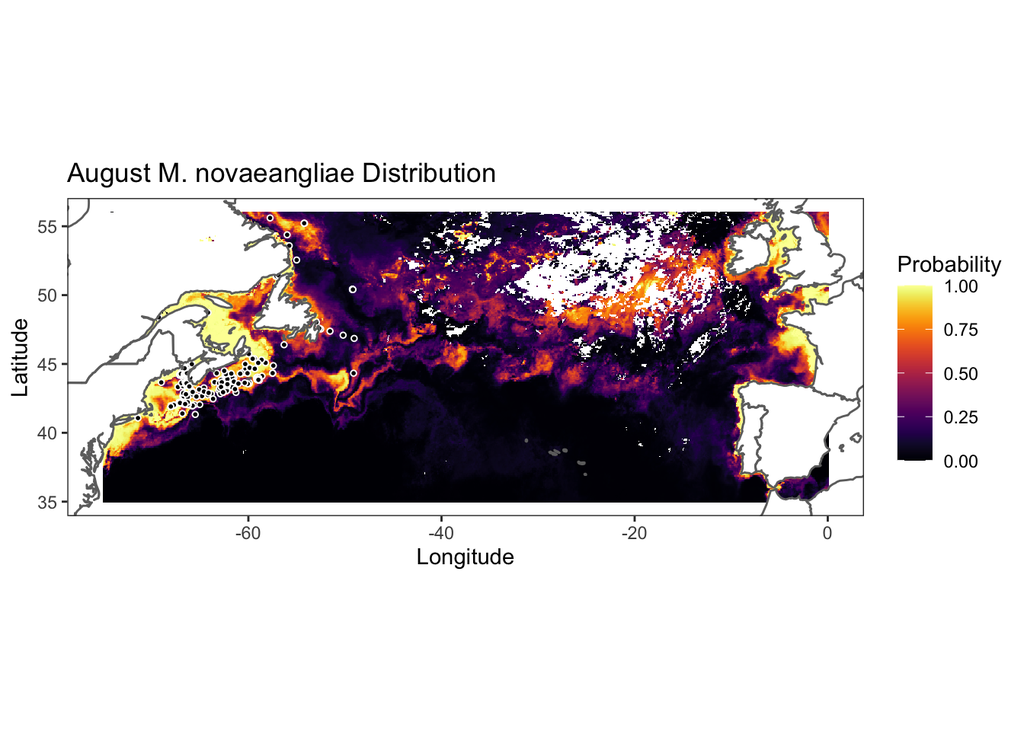

```r
# Load projection as a dataframe
proj_df <- raster::raster(file.path("M.novaeangliae/proj_current/proj_current_M.novaeangliae.grd")) %>%
  # Biomod2 computes probability 1000x higher than it actually is to save memory, so dividing
  # by 1000 will convert the probability back to a 0-1 scale
  `/`(1000) %>%
  as.data.frame(xy = TRUE) %>%
  dplyr::rename(prob = M.novaeangliae_AllData_RUN1_GAM)

#Plot map, probabilities, and sightings data
ggplot2::ggplot() +
  # Add probability data
  geom_tile(data = proj_df, aes(x, y, fill = prob)) +
  # Add probabilitiy color gradient and label
  scale_fill_gradientn(colours = inferno(500), limits = c(0,1), name = 'Probability', na.value = "white") +
  # Add sightings data
  geom_point(data = M.novaeangliae.biomod %>% dplyr::filter(pa == 1), mapping = aes(x = lon, y = lat), color = "white", fill = "black", pch = 21, cex = 1, stroke = 0.5) +
  labs(x = "Longitude",
       y = "Latitude",
       title = "August M. novaeangliae Distribution") +
  # Add world map data
  geom_polygon(data = worldmap, aes(long, lat, group = group), fill = NA, colour = "gray43") +
  coord_quickmap(xlim = c(round(min(proj_df$x)), round(max(proj_df$x))),
                 ylim = c(round(min(proj_df$y)), round(max(proj_df$y))),
                 expand = TRUE) +
  # Remove grid lines
  theme_bw() +
  theme(panel.grid.major = element_blank(), panel.grid.minor = element_blank())
```

The regions in yellow represent the parts of the domain where the model projects high probability of an M. novaeangliae occurrence. The regions in black indicate that the model projected a low probability of occurrence. We can see that the projection lines up relatively well with the M. novaeangliae sightings data.